# Estimates and xmin cutoff

Justin Pomeranz

Started 2025-04-22

## Overview

This document was written in response to a question from Charles Gagnon. The question is RE how comparable $\lambda$ estimates are when the body size samples have different estimates for the undersampling cutoff, e.g., the estimated $x_{min}$ from the `poweRlaw` package.

# Setup

## Libraries

```r
library(poweRlaw)
# install sizeSpectra if needed from Andrew Edwards gitHub
# Note that `remotes` package is also required
# install.packages("remotes")    # If you do not already have the "remotes" package
# remotes::install_github("andrew-edwards/sizeSpectra")
library(sizeSpectra)
library(tidyverse)
```

## Simulate data

Values are based on what could be expected in a benthic macroinvertebrate sample.

```r
set.seed(2112)
x <- rPLB(5000, b = -2, xmin = 0.1, xmax = 75)
```

- Make a dataframe with a `theta` column
- `theta` will be used to define the cutoff, e.g. the level below which body sizes are undersampled

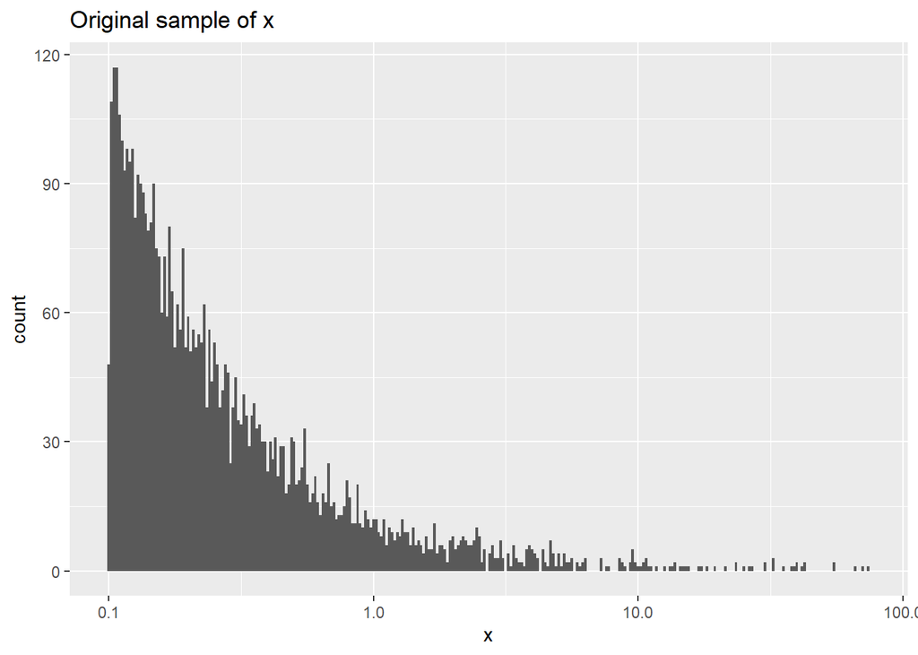

```r
dat1 <- data.frame(x = sort(x))

ggplot(dat1, aes(x = x)) +
  geom_histogram(binwidth = 0.01) +
  scale_x_log10() +
  labs(title = "Original sample of x")
```

- Create 2 data frames, each with a different cutoff

```r
dat2 <- dat1
dat1$theta <- 0.5
dat2$theta <- 1
```

- add a probability of sampling, based on if x >= theta

```r
dat1 <- dat1 |>
  mutate(pr = case_when(
    x < theta ~ 0.01,
    .default = 1
  ))
dat1 |>
  group_by(pr) |>
  count()
```

```
## # A tibble: 2 × 2
## # Groups:   pr [2]
##      pr     n
##   <dbl> <int>
## 1  0.01  4007
## 2  1      993
```

```r
obs1 <- dat1 |>
  sample_n(size = 1000, weight = pr)
obs1 |>
  group_by(pr) |>
  count()
```

```
## # A tibble: 2 × 2
## # Groups:   pr [2]
##      pr     n
##   <dbl> <int>
## 1  0.01    94
## 2  1      906
```

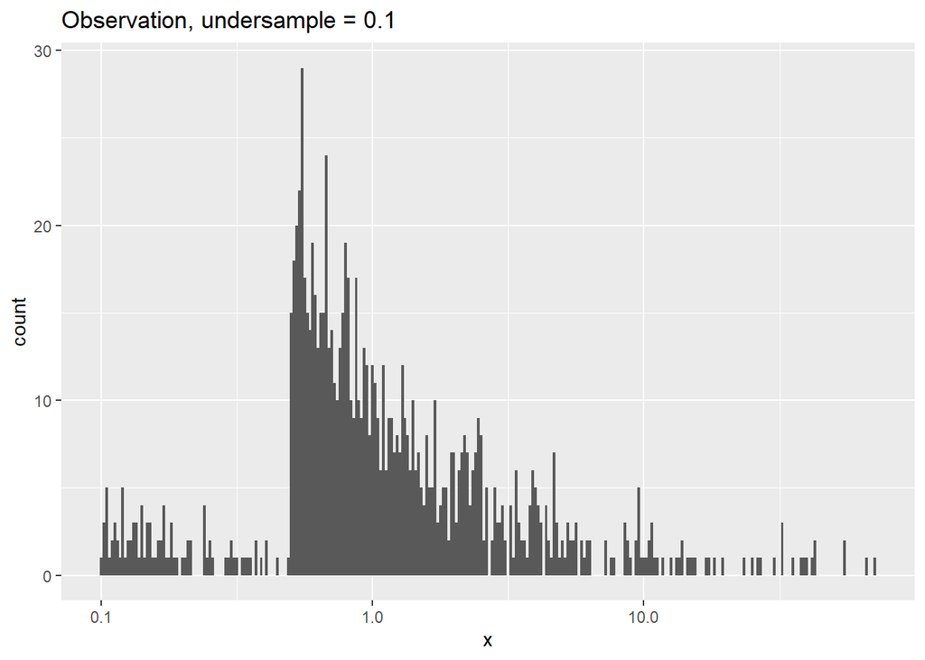

```r
ggplot(obs1, aes(x = x)) +
  geom_histogram(binwidth = 0.01) +
  scale_x_log10() +
  labs(title = "Observation, undersample = 0.1")
```

```r
powerlaw = conpl$new(obs1$x)
xmin1 = estimate_xmin(powerlaw)$xmin
xmin1
```

```
## [1] 0.4943465
```

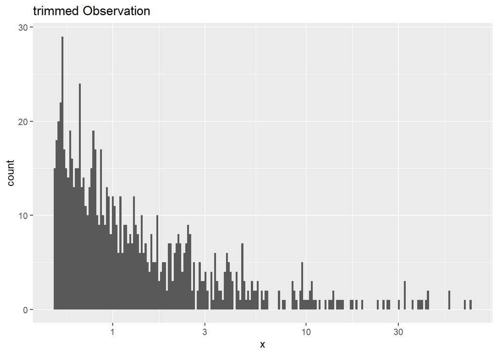

```r
# estimate lambda using size spectra
obs1$xmin = xmin1
trim1 <- obs1 |>
  filter(x > xmin)

ggplot(trim1, aes(x = x)) +
  geom_histogram(binwidth = 0.01) +
  scale_x_log10() +
  labs(title = "trimmed Observation")
```

```r
# estimate lambda from size spectra package
calcLike(
      negLL.fn = negLL.PLB, # continuous estimates of all individuals
      x = trim1$x, # the vector of data
      xmin = min(trim1$x), # the minimum body size
      xmax = max(trim1$x), # the maximum body size
      n = length(trim1$x), # the number of observations
      sumlogx = sum(log(trim1$x)), # sum of log-transformed data
      p = -1.5) # starting point, arbitrary number
```

```
## $MLE
## [1] -1.991783
##
## $conf
## [1] -2.063783 -1.921783
```

- dat2

```r
dat2 <- dat2 |>
  mutate(pr = case_when(
    x < theta ~ 0.01,
    .default = 1
  ))
dat2 |>
  group_by(pr) |>
  count()
```

```
## # A tibble: 2 × 2
## # Groups:   pr [2]
##      pr     n
##   <dbl> <int>
## 1  0.01  4512
## 2  1      488
```

```r
obs2 <- dat2 |>
  sample_n(size = 1000, weight = pr)
obs2 |>
  group_by(pr) |>
  count()
```

```
## # A tibble: 2 × 2
## # Groups:   pr [2]
##      pr     n
##   <dbl> <int>
## 1  0.01   512
## 2  1      488
```

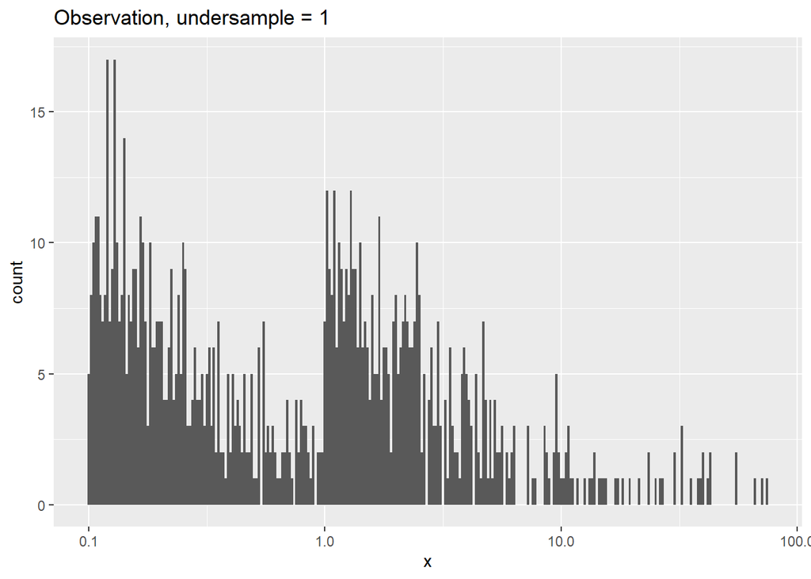

```r
ggplot(obs2, aes(x = x)) +
  geom_histogram(binwidth = 0.01) +
  scale_x_log10() +
  labs(title = "Observation, undersample = 1")
```

```r
powerlaw = conpl$new(obs2$x)
xmin2 = estimate_xmin(powerlaw)$xmin
xmin2
```

```
## [1] 1.264411
```

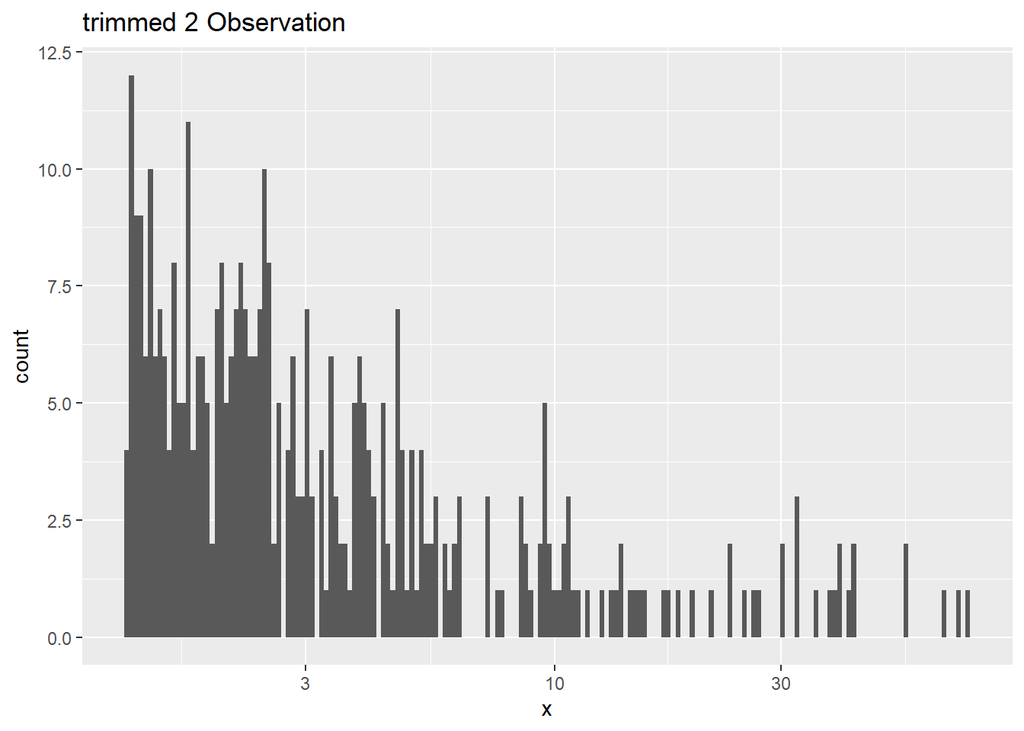

```r
# estimate lambda using size spectra
obs2$xmin = xmin2
trim2 <- obs2 |>
  filter(x > xmin)

ggplot(trim2, aes(x = x)) +
  geom_histogram(binwidth = 0.01) +
  scale_x_log10() +
  labs(title = "trimmed 2 Observation")
```

```r
# estimate lambda from size spectra package
calcLike(
      negLL.fn = negLL.PLB, # continuous estimates of all individuals
      x = trim2$x, # the vector of data
      xmin = min(trim2$x), # the minimum body size
      xmax = max(trim2$x), # the maximum body size
      n = length(trim2$x), # the number of observations
      sumlogx = sum(log(trim2$x)), # sum of log-transformed data
      p = -1.5) # starting point, arbitrary number
```

```
## $MLE
## [1] -1.970252
##
## $conf
## [1] -2.087252 -1.858252
```

# Functionalize this for testing

```r
test_xmin <- function(seed = 2112,
                      n_orig = 5000,
                      b = -2,
                      plb_xmin = 0.1,
                      plb_xmax = 75,
                      theta_value = 1,
                      pr_under = 0.01,
                      pr_over = 1,
                      binwidth = 0.01,
                      n_sub_sample = 1000){
  set.seed(seed)
  # sample body sizes
  x <- rPLB(n_orig, b = b, xmin = plb_xmin, xmax = plb_xmax)
  # make a dataframe with a theta column
  dat <- data.frame(x = sort(x),
                    theta = theta_value)
  # add a pr column; probability of being resampled
  dat <- dat |>
  mutate(pr = case_when(
    x < theta ~ pr_under,
    .default = pr_over
  ))
  # simulate an observed data set
  obs <- dat |>
    sample_n(size = n_sub_sample, weight = pr)

  # estimate the xmin for the observed data
  powerlaw = conpl$new(obs$x)
  est_xmin = estimate_xmin(powerlaw)$xmin
  # add estimated xmin to observed data set
  obs$est_xmin = est_xmin
  trim <- obs |>
    filter(x > est_xmin)

  # estimate lambda from size spectra package
  est_lambda <- calcLike(
    negLL.fn = negLL.PLB, # continuous estimates of all individuals
    x = trim1$x, # the vector of data
    xmin = min(trim1$x), # the minimum body size
    xmax = max(trim1$x), # the maximum body size
    n = length(trim1$x), # the number of observations
    sumlogx = sum(log(trim1$x)), # sum of log-transformed data
    p = -1.5) # starting point, arbitrary number

  out <- data.frame(est_xmin = est_xmin,
             actual_xmin = theta_value,
             est_lambda = est_lambda$MLE,
             est_lambda_low = est_lambda$conf[1],
             est_lambda_high = est_lambda$conf[2],
             actual_lamba = b)
  # combine obs and trimmed data for plotting
  obs$group <- "observed"
  trim$group <- "trimmed"
  d2 <- bind_rows(obs, trim)
  p <- ggplot(d2, aes(x = x)) +
    geom_histogram(binwidth = binwidth) +
    scale_x_log10() +
    facet_wrap(~group)
  print(p)


  return(out)
}
```

- Use the function

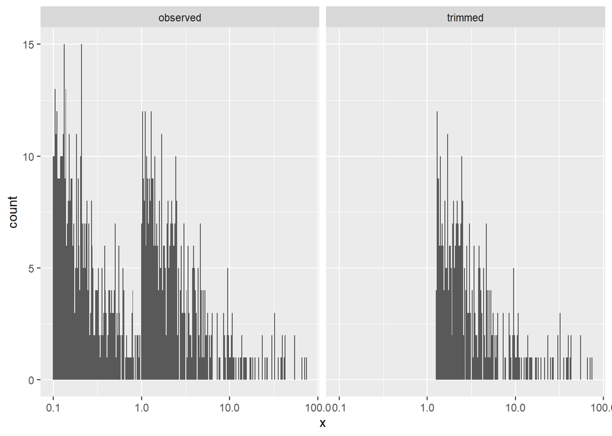

```
##   est_xmin actual_xmin est_lambda est_lambda_low est_lambda_high actual_lamba
## 1 1.264411           1  -1.991783      -2.063783       -1.921783           -2
```

```r
# default values
test_xmin(theta_value = 1)
```

### changing `theta` values

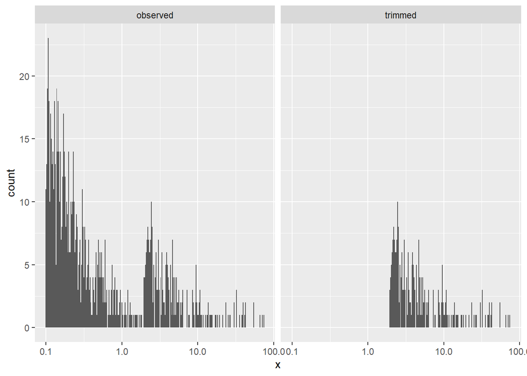

```
##   est_xmin actual_xmin est_lambda est_lambda_low est_lambda_high actual_lamba
## 1 1.934437           2  -1.991783      -2.063783       -1.921783           -2
```

```r
test_xmin(theta_value = 2)
```

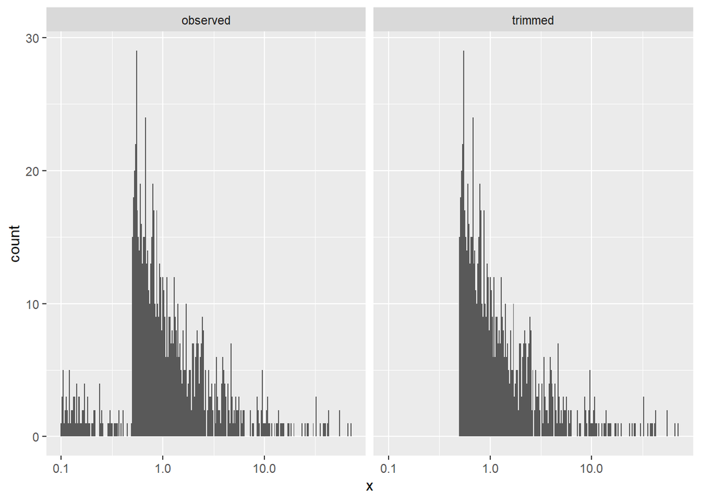

```
##    est_xmin actual_xmin est_lambda est_lambda_low est_lambda_high actual_lamba
## 1 0.4943465         0.5  -1.991783      -2.063783       -1.921783           -2
```

```r
test_xmin(theta_value = 0.5)
```

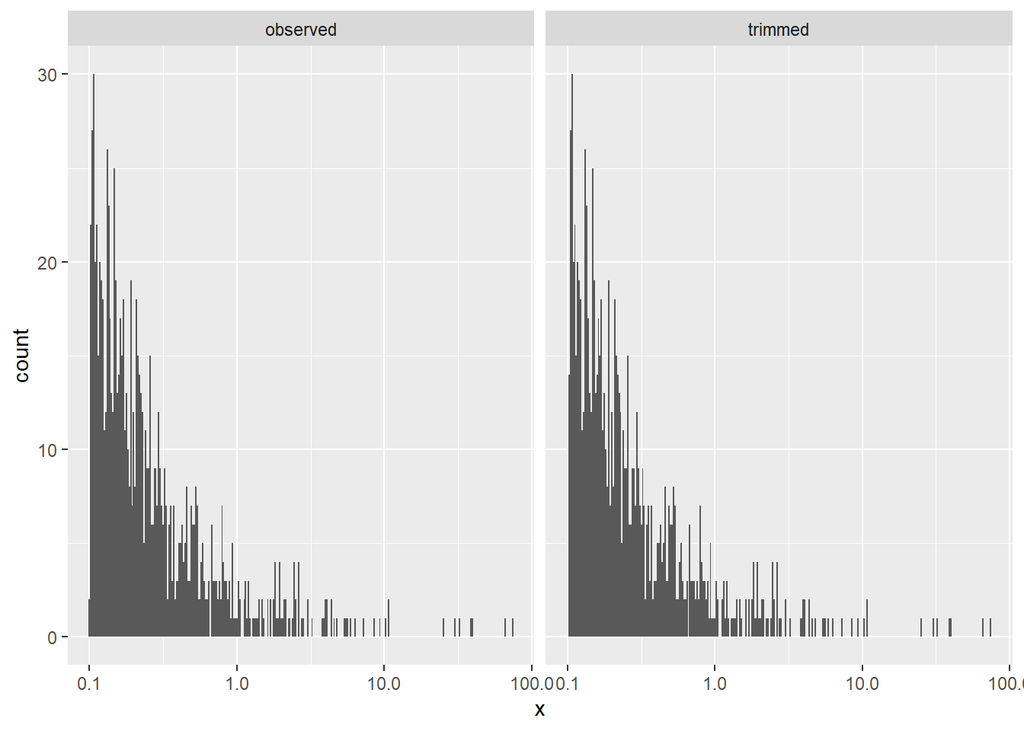

```
##    est_xmin actual_xmin est_lambda est_lambda_low est_lambda_high actual_lamba
## 1 0.1022552         0.1  -1.991783      -2.063783       -1.921783           -2
```

```r
test_xmin(theta_value = 0.1)
```

- with high cutoffs, the function does not work well

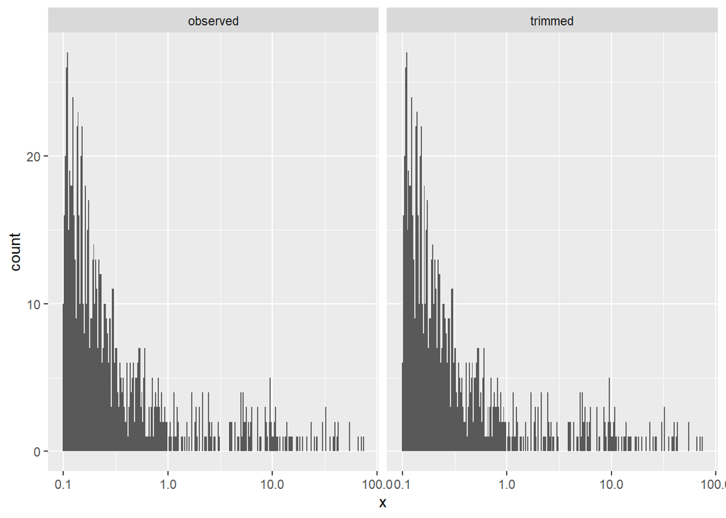

```
##    est_xmin actual_xmin est_lambda est_lambda_low est_lambda_high actual_lamba
## 1 0.1000875           5  -1.991783      -2.063783       -1.921783           -2
```

```r
test_xmin(theta_value = 5)
```

- I think this is an artifact of the way I sub sample
- If we also increase the body size ranges, it does seem to still work

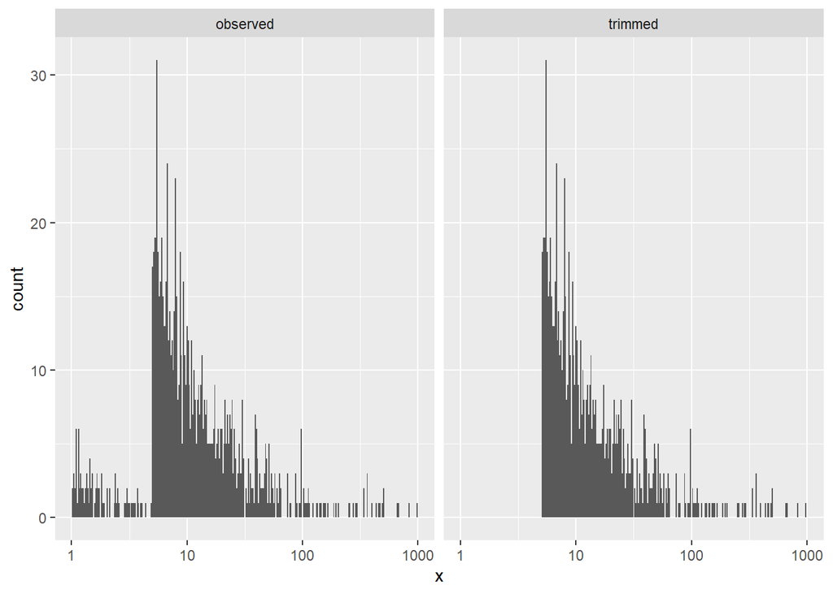

```
##   est_xmin actual_xmin est_lambda est_lambda_low est_lambda_high actual_lamba
## 1 5.053938           5  -1.991783      -2.063783       -1.921783           -2
```

```r
test_xmin(theta_value = 5,
          plb_xmin = 1,
          plb_xmax = 1000)
```

- I think this is because the probability of sampling a really large body size in `rPLB()` is rare to begin with.
- Let’s increase the original sample size and see if that helps

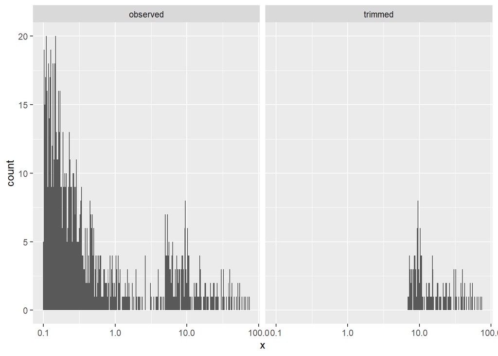

```
##   est_xmin actual_xmin est_lambda est_lambda_low est_lambda_high actual_lamba
## 1 6.957806           5  -1.991783      -2.063783       -1.921783           -2
```

```r
test_xmin(theta_value = 5,
          n_orig = 10000)
```

- I think this goves us enough large body sizes to actually sub sample them.
- When there are not many sizes present in the original, the sub sample still ends up with a lot of small sizes, even though the probability of sampling it is small i.e., 1 %
- Oh, wait… I just remembered the default in `sample_n(replace = FALSE)`.
- Setting that to `TRUE` may change this, and it might still appropriately undersample the small body sizes.

# Future tests

These would likely require modifying the function I wrote above

1. Does using the “wrong” cutoff still lead to better estimates?
- i.e., Charles has cut offs of mostly ~2-3.
- Would using a global value of 2.5 be ok?
- Try different cutoffs and estimate lambda to see distribution
- I’m guessing it will be ok, but probably still introducing some error
- I bet it wil be greatest for those sites that had estimated xmins at ~9
- Does overcompensating the cutoff still lead to reasonable estimates?
  - i.e., global cutoff of your max estimate at ~9?
2. How “off” are lambda estimates in untrimmed data?
- I’m guessing off by a lot
- My intuition tells me that it’s better to get accurate lambda estimates, regardless of where the cutoff is.
- If you estimate lambda with undersampled data, I bet your lambdas are wrong, so comparing them may be meaningless. i.e., this random number is different from this other random number, and they are both different from this number that is correct.